# Challenge_7: Concepts and Practices of Research Design for a Data Science Project

weekly_challenges

challenge_7

Solutions

Author

Rachana Ponagandla

Published

November 27, 2023

**Make sure you change the author’s name in the above YAML header.**

## Setup

If you have not installed the following packages, please install them before loading them.

```r
library(tidyverse)
library(readxl)
library(haven) #for loading other datafiles (SAS, STATA, SPSS, etc.)
library(stringr) # if you have not installed this package, please install it.
library(ggplot2) # if you have not installed this package, please install it.
library(lubridate)
library(zoo)
knitr::opts_chunk$set(echo = TRUE, warning=FALSE, message=FALSE)
```

## Challenge Overview

In this challenge, we will apply the knowledge about research design and other topics covered in lectures so far to the dataset presented.

There will be coding components and writing components. Please read the instructions for each part and complete your challenges.

## Part 1. Choose one of the following datasets to do a simple practice of research design and hypothesis testing (50%)

Dataset 1: The General Social Survey (2022). You can find more information about this data project at https://gss.norc.org/About-The-GSS. A codebook explaining the definition of each variable and column is also included.

Dataset 2: The Covid-19 Reports in Massachusetts. The datasets are stored in an Excel file of multiple sheets. You can find more information about this data project in the “Introduction”, “Definition”, “Notes”, and “Data Dictionary” tabs in the Excel file.

1. **Read the data you choose in R. (5%)**

   For GSS, there is only one data sheet (.dta).

   For the MA Covid-19 reports, you can choose **one of the four datasheets(tabs in Excel)** to read (“Weekly Cases and Deaths”, “Case and Death Demographics”, “County Data”, and “City and Town Data”).

   I’m using Covid-19 reports dataset and I’m choosing the “Case and Death Demographics” datasheet.

```r
covid_data <- read_excel("_data/covid-19-dashboard-11-16-23.xlsx", sheet = "Case and Death Demographics")
head(covid_data)
```

| Season | Week Start Date | Week End Date | Group | Subgroup | Estimated population | Percent of the population | Cases during this week | Week case rate | Cumulative cases | Cumulative case rate | Deaths during this week | Week death rate | Cumulative deaths | Cumulative death rate | Last updated |
| --- | --- | --- | --- | --- | --- | --- | --- | --- | --- | --- | --- | --- | --- | --- | --- |
| 2023-2024 | 2023-07-02 | 2023-07-08 | Race and Hispanic ethnicity | Hispanic, all races | 878944.17459859001 | 0.12502909706909601 | 131 | 14.904245774178678 | 131 | 14.904245774178678 | 0 | 0 | 0 | 0 | 2023-11-16 |
| 2023-2024 | 2023-07-02 | 2023-07-08 | Race and Hispanic ethnicity | Asian, not Hispanic | 510096.11066676001 | 0.072560758667351705 | 29 | 5.6852031202694997 | 29 | 5.6852031202694997 | 1 | 0.19604148690584483 | 1 | 0.19604148690584483 | 2023-11-16 |
| 2023-2024 | 2023-07-02 | 2023-07-08 | Race and Hispanic ethnicity | Black or African-American, not Hispanic | 476930.24482826999 | 0.067842941109490296 | 53 | 11.112736207175098 | 53 | 11.112736207175098 | 0 | 0 | 0 | 0 | 2023-11-16 |
| 2023-2024 | 2023-07-02 | 2023-07-08 | Race and Hispanic ethnicity | Alaskan Native or American Indian, not Hispanic | 9939.37961473 | 0.0014138687013020099 | 0 | 0 | 0 | 0 | 0 | 0 | 0 | 0 | 2023-11-16 |
| 2023-2024 | 2023-07-02 | 2023-07-08 | Race and Hispanic ethnicity | Other race, not Hispanic | ** | ** | 23 | * | 23 | * | 1 | * | 1 | * | 2023-11-16 |
| 2023-2024 | 2023-07-02 | 2023-07-08 | Race and Hispanic ethnicity | Native Hawaiian or Pacific Islander, not Hispanic | 1841.1187200300001 | 0.00026189764698934402 | 0 | 0 | 0 | 0 | 0 | 0 | 0 | 0 | 2023-11-16 |

2. **Answer the following questions.**

   (1) what is the structure (dimension) of the data? **(2.5%)**

   The data has 380 rows and 16 columns

   ```r
   dim(covid_data)
   ```

   ```
   [1] 380  16
   ```

   (2) what is the unit of observation? **(2.5%)**

   The unit of observation in this data is demographic subgroup within a specific week. Each row in the dataset represents the Covid-19 case and death statistics for a specific demographic subgroup(such as a specific race or ethnic group or age) during a specific week.
3. **Read the overview introduction, codebook (for the GSS data), and other related information about the data (for the Covid-19 data). Now browse the data loaded in R, it seems like there are many different questions this data can answer.** **Based on the class lecture and KKV’s reading about “good research questions”, please propose ONE research question that can be answered using this data. (5%)**

   Does age significantly influence the number of Covid-19 related deaths in Massachusetts during the 2023-2024 season?
4. **Based on the research question you proposed above, propose a hypothesis about a possible relationship between two items. (5%)**

   Hypothesis: The number of Covid-19 related deaths in Massachusetts during the 2023-2024 season is significantly higher in older age groups compared to younger age groups.
5. **Based on the hypothesis proposed, please select variables/columns in the data to measure the corresponding concepts in the hypothesis statement. You should select at least one variable/column to measure each concept.**

   **You should also specify which variables/columns you choose and explain why they are the proper ones to measure the concepts. (10%)**

   **Instruction:** Don’t just answer, “They are reliable and valid”. Instead, you should discuss more why they are reliable (can consistently produce the same results regardless of the same results regardless different times and contexts) and valid (why it is better than other possible or alternative variables/columns). You can find the concepts of validity and reliability in the Nov 20 lecture and the slides (p23-25). There are also more in-depth introductions online, such as [this page](http://media.acc.qcc.cuny.edu/faculty/volchok/Measurement_Volchok/Measurement_Volchok6.html).

   **Answer**: Based on the hypothesis, we can select the following variables/columns from the data:

   **Group and Subgroup**: These variables categorize individuals into different demographic groups, which include age groups. They directly represent the independent variable (age group) in our hypothesis. They are reliable because they consistently categorize individuals into the same demographic groups across different times and contexts. They are valid because they directly group the population based on age, which is the variable of interest in your hypothesis. The “Group” column indicates the type of demographic information (e.g., “Age”), and the “Subgroup” column provides the specific categories within each type (e.g., “<5 years”, “5-19 years”). This allows us to accurately identify and compare different age groups, which is exactly what we need for our hypothesis.

   **Deaths during this week**: This variable represents the number of Covid-19 related deaths that occurred during a specific week. This variable is reliable as it should consistently represent the same thing (number of deaths) across different times and contexts. This means that the way deaths are counted and recorded does not change over time. It’s also valid for our purposes as it directly measures the Covid-19 related deaths. Each entry in this column represents the actual number of deaths that occurred during a specific week.
6. **Use the code we learned in the previous week to conduct descriptive statistics for the two variables/columns you selected above. You should present the following information in your descriptive statistics: range, average, standard deviation, the number of NAs, and the number of unique values. (5%)**

   Since age groups are categorical data, measures like range, average, and standard deviation are not applicable. Instead we can count number of unique age groups, number of NAs in age groups, Frequency of each age group.

   Note that I’ve filtered out subgroup with “Unknown age” value.

   ```r
   research_data <- covid_data %>%
     select("Group", "Subgroup", "Deaths during this week")

   research_data <- research_data %>%
     filter(Group == "Age" & Subgroup != "Unknown age")  %>%
     #mutate("Age_group" = Subgroup) %>%
     select(Subgroup, `Deaths during this week`)

   unique_age_groups <- length(unique(research_data$Subgroup))
   na_age_groups <- sum(is.na(research_data$Subgroup))

   cat("Number of unique age groups: ", unique_age_groups, "\n",
       "Number of NAs in age groups: ", na_age_groups, "\n")
   ```

   ```
   Number of unique age groups:  7
    Number of NAs in age groups:  0
   ```

   ```r
   age_group_freq <- table(research_data$Subgroup)

   cat("Frequency of each age group:\n")
   ```

   ```
   Frequency of each age group:
   ```

   ```r
   print(age_group_freq)
   ```

   ```
      <5 years 20-34 years 35-49 years  5-19 years 50-64 years 65-79 years
            19          19          19          19          19          19
     80+ years
            19
   ```

   Descriptive statistics for Deaths during this week column:

   ```r
   research_data$`Deaths during this week` <- as.numeric(research_data$`Deaths during this week`)

   range_deaths <- range(research_data$`Deaths during this week`, na.rm = TRUE)
   average_deaths <- mean(research_data$`Deaths during this week`, na.rm = TRUE)
   sd_deaths <- sd(research_data$`Deaths during this week`, na.rm = TRUE)
   na_deaths <- sum(is.na(research_data$`Deaths during this week`))
   unique_deaths <- length(unique(research_data$`Deaths during this week`))

   cat("Range of deaths: ", range_deaths, "\n",
       "Average deaths: ", average_deaths, "\n",
       "Standard deviation of deaths: ", sd_deaths, "\n",
       "Number of NAs in deaths: ", na_deaths, "\n",
       "Number of unique values in deaths: ", unique_deaths)
   ```

   ```
   Range of deaths:  0 28
    Average deaths:  2.977444
    Standard deviation of deaths:  5.561592
    Number of NAs in deaths:  0
    Number of unique values in deaths:  21
   ```

7. **Plot one univariate graph for each of the variables/columns. (5%)**

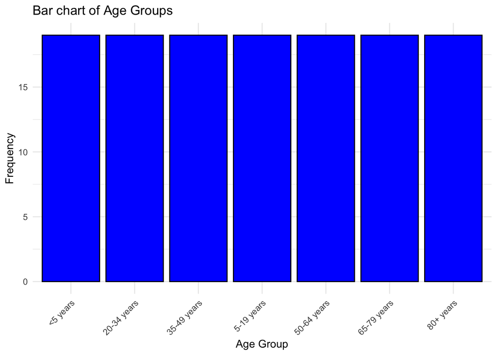

   ```r
   ggplot(research_data, aes(x=Subgroup)) +
     geom_bar(fill="blue", color="black") +
     theme_minimal() +
     theme(axis.text.x = element_text(angle = 45, hjust = 1)) +
     labs(title="Bar chart of Age Groups",
          x="Age Group",
          y="Frequency")
   ```

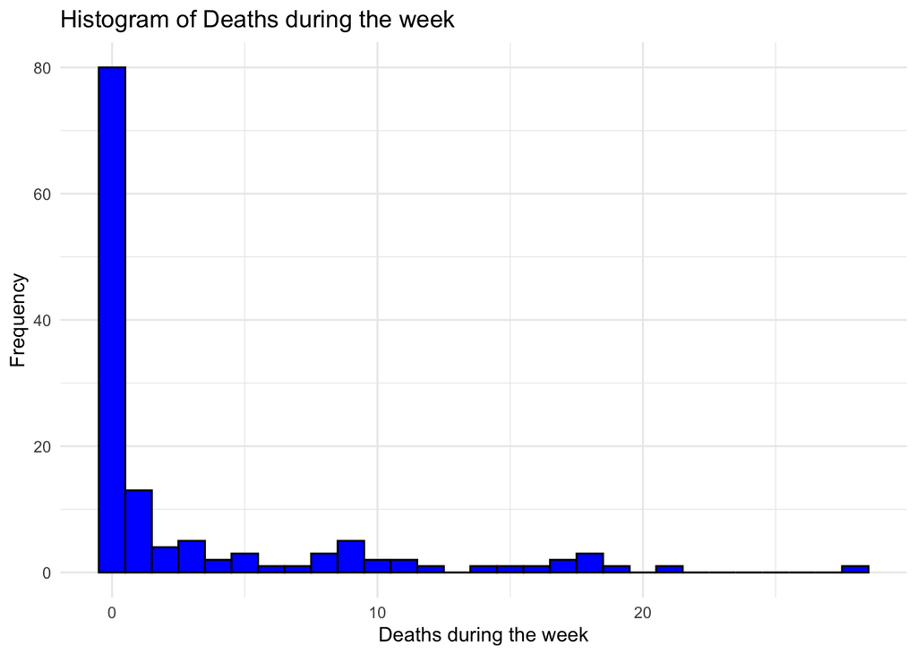

   ```r
   ggplot(research_data, aes(x=`Deaths during this week`)) +
     geom_histogram(binwidth=1, fill="blue", color="black") +
     theme_minimal() +
     labs(title="Histogram of Deaths during the week",
          x="Deaths during the week",
          y="Frequency")
   ```

8. **Finally, plot a graph to visually test the hypothesis you propose. Based on the visual evidence, do you see any potential correlation between the two variables? (10%)**

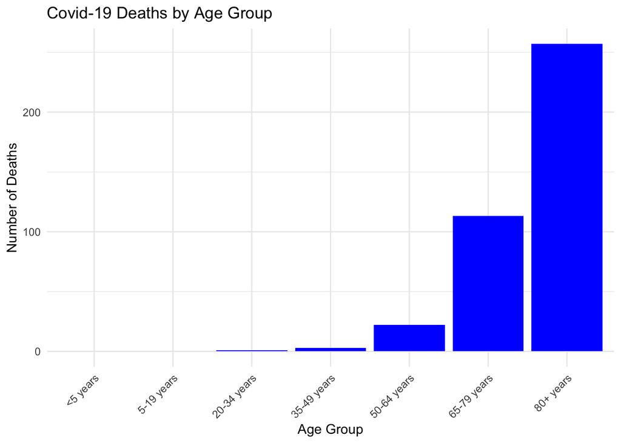

   ```r
   research_data <- aggregate(`Deaths during this week` ~ Subgroup, research_data, sum)
   age_order <- c("<5 years", "5-19 years", "20-34 years", "35-49 years", "50-64 years", "65-79 years", "80+ years")
   research_data$Subgroup <- factor(research_data$Subgroup, levels = age_order, ordered = TRUE)

   ggplot(research_data, aes(x=Subgroup, y=`Deaths during this week`)) +
     geom_bar(stat="identity", fill="blue") +
     theme_minimal() +
     theme(axis.text.x = element_text(angle = 45, hjust = 1)) +
     labs(title="Covid-19 Deaths by Age Group",
          x="Age Group",
          y="Number of Deaths")
   ```

## Part 2. Reviewing the findings of a graph by examining the raw data.

1. **Please briefly describe the major findings of this graph. (5%)**

   (1) Read the provided WVS data. The dataset is large, so you must subset it before analyzing it. **Please keep only the following columns: respondents’ country(V2), age(V236), and the question for plotting (V162).** You also need to filter only the observations in the six countries mentioned above: Sweden, Australia, Netherlands, United States, New Zealand, and Britain/United Kingdom. **(10%)**

   Note: all the columns, including those that are measured categorically, are represented by numbers. You must check out the WVS5 codebook to identify what the numerical values mean (especially for V2-country, see p57 of the codebook).

   ```r
   data <- read_rds("_data/WVS5.rds")

   data <- data[, c("V2", "V236", "V162")]

   data <- data %>%
     filter(V2 %in% c(752, 36, 528, 840, 554, 826))

   head(data)
   ```

   | V2 | V236 | V162 |
   | --- | --- | --- |
   | 36 | 1921 | 10 |
   | 36 | 1939 | 10 |
   | 36 | 1954 | 10 |
   | 36 | 1947 | 10 |
   | 36 | 1965 | 9 |
   | 36 | 1980 | 4 |

   (2) Conduct descriptive statistics to show these three columns’ unique values, means, ranges, and numbers of NA. You can plot univariate graphs as we did in challenge#4 or apply the summary statistics function as in challenge#3. Just do either approach. **(10%）**

   Answer:

   As V2 is a categorical variable which represents country using country codes, measures like range, mean are not applicable. Instead we can count number of unique values, number of NAs and show the unique values.

   ```r
     cat("Column: V2","\n",
         "Number of NAs: ", sum(is.na(data$V2)), "\n",
         "Number of unique values: ", length(unique(data$V2)), "\n",
         "Unique values: ", unique(data$V2), "\n")
   ```

   ```
   Column: V2
    Number of NAs:  0
    Number of unique values:  6
    Unique values:  36 528 554 752 826 840
   ```

   ```r
   filtered_data <- data[data$V236 != -2,]

   cat("Column: V236","\n",
   "Mean: ", mean(filtered_data$V236, na.rm = TRUE), "\n",
   "Range: ", min(filtered_data$V236, na.rm = TRUE), " to ", max(filtered_data$V236, na.rm = TRUE), "\n",
   "Number of NAs: ", sum(is.na(data$V236)) + sum(data$V236 == -2), "\n",
   "Number of unique values: ", length(unique(data$V236)), "\n",
   "Unique values: ", unique(data$V236), "\n")
   ```

   ```
   Column: V236
    Mean:  1957.317
    Range:  1910  to  1991
    Number of NAs:  37
    Number of unique values:  80
    Unique values:  1921 1939 1954 1947 1965 1980 1934 1915 1959 1960 1946 1982 1927 1953 1922 1961 1983 1924 1987 1945 1930 1938 1932 1933 1976 1950 1977 1962 1981 1957 1979 1936 1944 1949 1951 1926 1970 1952 1973 1975 1967 1958 1984 1948 1928 1937 1941 1969 1940 1978 1955 1956 1942 1920 1966 1935 196…
   ```

   ```r
   filtered_data <- data[data$V162 > 0,]

   cat("Column: V162","\n",
   "Mean: ", mean(filtered_data$V162, na.rm = TRUE), "\n",
   "Range: ", min(filtered_data$V162, na.rm = TRUE), " to ", max(filtered_data$V162, na.rm = TRUE), "\n",
   "Number of NAs: ", sum(is.na(data$V162)) + sum(data$V162 < 0), "\n",
   "Number of unique values: ", length(unique(data$V162)), "\n",
   "Unique values: ", unique(data$V162), "\n")
   ```

   ```
   Column: V162
    Mean:  8.926873
    Range:  1  to  10
    Number of NAs:  1084
    Number of unique values:  14
    Unique values:  10 9 4 8 -2 7 5 6 3 1 2 -1 -4 -5
   ```

   (3) (Optional) Please replicate the graph of the NYT article.

   ```r
   #type your code here
   ```

   (4) Now, please plot a graph to show the relationship between the decades of birth (x-axis) and the average level of the response scores to the question “importance of democracy” (y-axis) for each of the six countries. You can use facet_grid or facet_wrap to combine multiple graphs into a matrix of panels. **(15%)**

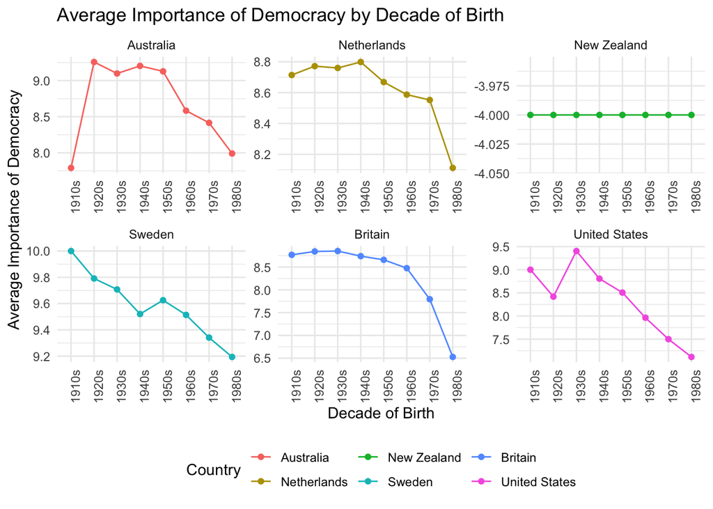

   ```r
   country_codes <- c('752' = 'Sweden', '36' = 'Australia', '528' = 'Netherlands',
                      '840' = 'United States', '554' = 'New Zealand', '826' = 'Britain')
   names(country_codes) <- as.numeric(names(country_codes))
   country_codes <- country_codes[order(as.numeric(names(country_codes)))]

   data$Country <- factor(data$V2, labels = country_codes)


   data <- data %>%
     filter(V2 %in% c(752, 36, 528, 840, 554, 826)) %>%
     mutate(Decade_of_Birth = cut(V236, breaks = seq(1910, 1990, by = 10),
                                  labels = c("1910s", "1920s", "1930s", "1940s",
                                             "1950s", "1960s", "1970s", "1980s"), include.lowest = TRUE)) %>%
     drop_na(Decade_of_Birth)

   data_summary <- data %>%
     group_by(Country, Decade_of_Birth) %>%
     summarise(Average = mean(V162, na.rm = TRUE)
               ) %>%
     ungroup()

   ggplot(data_summary, aes(x = Decade_of_Birth, y = Average, group = Country, color = Country)) +
     geom_line() +
     geom_point() +
     facet_wrap(~Country, scales = 'free') +
     theme_minimal() +
     labs(title = "Average Importance of Democracy by Decade of Birth",
          x = "Decade of Birth",
          y = "Average Importance of Democracy",
          color = "Country") +
     theme(legend.position = "bottom",
           axis.text.x = element_text(angle = 90, hjust = 1))
   ```

3. **Describe what you find from the graph you made above. Compared to the graph on NYT, what’s in common, or what’s different? Please type your answer below. (5%)**

   **Findings from the graph:**  
   The graph depicts the average importance score of democracy by respondents from six different countries, broken down by their decades of birth.

   I can observe that the average importance of democracy is lesser in younger generations compared to the older generations in Australia, Sweden, Britain, Netherlands and United States.

   Overall, we can say that except for New Zealand, all other 5 countries see a decline in the average importance of democracy in younger generations compared to older generations.

   **Differences between plotted graph and NYT graph:**

   NYT graph presents democracy data as percentages of the population that find it essential to live in a democracy, whereas our graph used average importance scores of democracy answered by people of different generations. Both measure 2 different but relevant things. Let’s compare 2 graphs starting from 1930s to be in sync.

   I can also observe that the overall decline in the trend is very high in NYT graph compared to the above plotted graph.

   **Commonalities with graph on NYT:**

   Although both graphs measure different trends but they are relevant in telling about the importance of democracy among generations. The trend for Sweden, United States and Netherlands for both the graphs from 1930s to 1980s are almost the same. Overall, we can observe from both the graphs that importance of democracy in the younger generations is less when compared to the older generations.
4. **Your client wants to hear your conclusion. Do you agree with the argument presented by the graph and the NYT article? Should we really worry about the decline? This is an op-ed question. Please type your answer below. (5%)**

   Yes, I agree with the argument presented by the graph and the NYT article. We need to worry about the decline because the observed decline in the importance of democracy among younger generations in both the plotted graph and the NYT article is consistent across most of the countries, suggesting a real trend that needs attention. I can’t say much about decline in New Zealand because of unavailable data on ratings. Particularly in Australia, Sweden, Netherlands, United States and Britain, the decline is more and we need to pay attention.